# Exploring Bulgarian Districts and Whether They Exhibit Spatial Spillovers

Milena Atanasova

### Read and explore the data

```r
library(spdep); library(sf); library(tmap); library(leaflet)
```

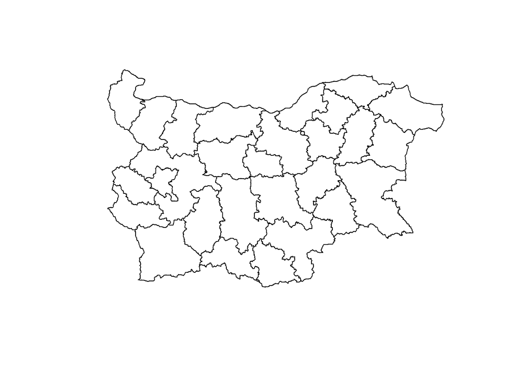

```r
bulgaria <- st_read("C:\\Users\\User\\Documents\\UNITN\\Geospatial\\For_GITHUB_project\\Plovdiv_Infographics\\Data\\Climate\\gdf_bg_climateinfo.geojson")
plot(st_geometry(bulgaria))
```

```r
dim(bulgaria)
```

```
## [1] 28 10
```

```r
names(bulgaria)
```

```
##  [1] "NAME_LATN"             "NUTS_NAME"             "Pop_2019"
##  [4] "Pop_city"              "Pop_villag"            "Area"
##  [7] "precipitation_average" "temperature_average"   "wind_speed_average"
## [10] "geometry"
```

```r
str(bulgaria)
```

```
## Classes 'sf' and 'data.frame':   28 obs. of  10 variables:
##  $ NAME_LATN            : chr  "Sofia" "Burgas" "Dobrich" "Shumen" ...
##  $ NUTS_NAME            : chr  "София" "Бургас" "Добрич" "Шумен" ...
##  $ Pop_2019             : int  226671 409265 171809 172262 122546 232568 236305 469885 82835 127001 ...
##  $ Pop_city             : int  139560 313132 118492 105478 77180 164538 158186 394795 53774 81689 ...
##  $ Pop_villag           : int  87111 96133 53317 66784 45366 68030 78119 75090 29061 45312 ...
##  $ Area                 : int  7064 7752 4719 3396 4132 4664 4643 3823 3034 3629 ...
##  $ precipitation_average: num  54.1 47.6 41.6 47.4 52.5 ...
##  $ temperature_average  : num  7.92 11.84 11.07 10.67 9.58 ...
##  $ wind_speed_average   : num  2.92 2.93 3.56 2.77 2.57 ...
##  $ geometry             :sfc_MULTIPOLYGON of length 28; first list element: List of 1
##   ..$ :List of 1
##   .. ..$ : num [1:867, 1:2] 23.4 23.4 23.4 23.4 23.4 ...
##   ..- attr(*, "class")= chr [1:3] "XY" "MULTIPOLYGON" "sfg"
##  - attr(*, "sf_column")= chr "geometry"
##  - attr(*, "agr")= Factor w/ 3 levels "constant","aggregate",..: NA NA NA NA NA NA NA NA NA
##   ..- attr(*, "names")= chr [1:9] "NAME_LATN" "NUTS_NAME" "Pop_2019" "Pop_city" ...
```

```r
head(bulgaria)
```

|  | NAME_LATN | NUTS_NAME | Pop_2019 | Pop_city | Pop_villag | Area | precipitation_average | temperature_average | wind_speed_average | geometry |
| --- | --- | --- | --- | --- | --- | --- | --- | --- | --- | --- |
| 1 | Sofia | София | 226671 | 139560 | 87111 | 7064 | 54.08557 | 7.917374 | 2.915912 |  |
| 2 | Burgas | Бургас | 409265 | 313132 | 96133 | 7752 | 47.58953 | 11.841585 | 2.929849 |  |
| 3 | Dobrich | Добрич | 171809 | 118492 | 53317 | 4719 | 41.55063 | 11.072057 | 3.560082 |  |
| 4 | Shumen | Шумен | 172262 | 105478 | 66784 | 3396 | 47.43396 | 10.667516 | 2.766465 |  |
| 5 | Lovech | Ловеч | 122546 | 77180 | 45366 | 4132 | 52.51208 | 9.579293 | 2.566308 |  |
| 6 | Veliko Tarnovo | Велико Търново | 232568 | 164538 | 68030 | 4664 | 49.03355 | 11.425287 | 2.499862 |  |

# Creating spatial weights matrices

Define the neighbourhood relationships among the spatial units. There are differnet methods in which a weight matrix can be defined. Below are shown some examples.

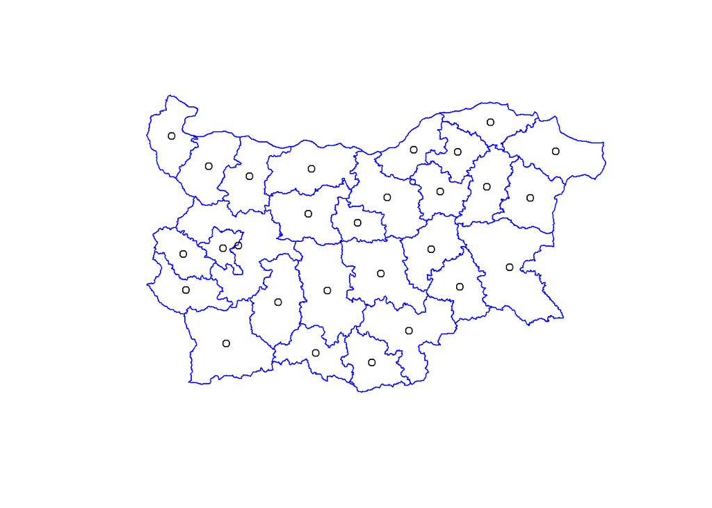

```r
# Spatial neighbors
coords <- st_centroid(st_geometry(bulgaria)) #unique reference spatial coordinate
plot(st_geometry(bulgaria), border="blue")
plot(coords, add = TRUE)
```

```r
# For Sofia, as its shape is particular, the centroid is very close to the border with the region of Sofia capital.
```

## Defining neighbors

#### 1.KNN

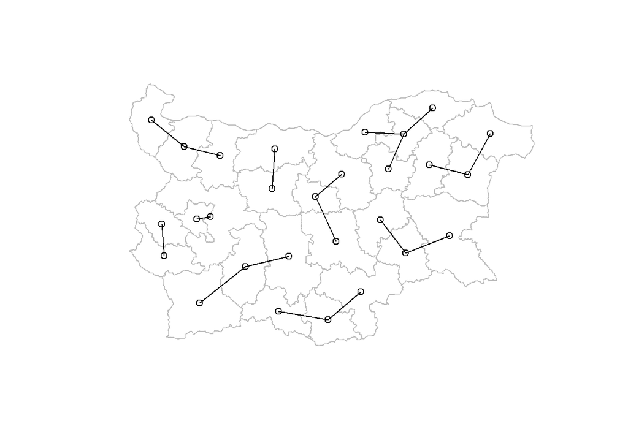

```r
knn1BG <- knn2nb(knearneigh(coords,k=1))
plot(st_geometry(bulgaria), border="grey")
plot(knn1BG, coords, add=TRUE)
```

#### 2.Critical cut-off neighborhood

```r
#minimum threshold distance
knn1IT <- knn2nb(knearneigh(coords,k=1))
all.linkedT <- max(unlist(nbdists(knn1IT, coords)))
all.linkedT
```

```
## [1] 74.55625
```

```r
dnb75 <- dnearneigh(coords, 0, 75); dnb75
```

```
## Neighbour list object:
## Number of regions: 28
## Number of nonzero links: 72
## Percentage nonzero weights: 9.183673
## Average number of links: 2.571429
```

```r
dnb100 <- dnearneigh(coords, 0, 100); dnb100
```

```
## Neighbour list object:
## Number of regions: 28
## Number of nonzero links: 144
## Percentage nonzero weights: 18.36735
## Average number of links: 5.142857
```

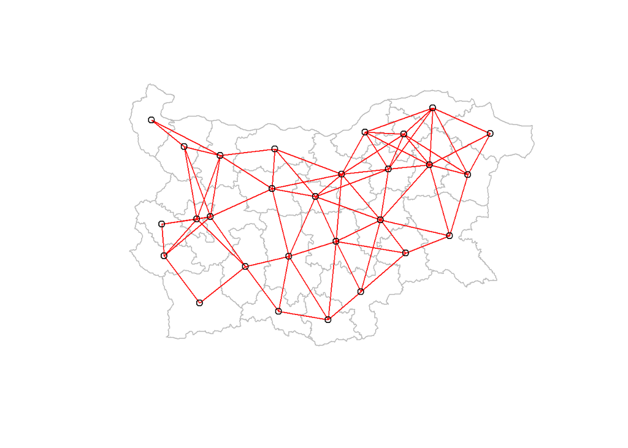

```r
plot(st_geometry(bulgaria), border="grey")
plot(dnb75, coords, add=TRUE, col="blue")
plot(dnb100, coords, add=TRUE, col="red")
```

#### 3.Contiguity-based neighbourhood

```r
# if share a common boundary

contnb_q <- poly2nb(bulgaria, queen=T)
contnb_q
```

```
## Neighbour list object:
## Number of regions: 28
## Number of nonzero links: 122
## Percentage nonzero weights: 15.56122
## Average number of links: 4.357143
```

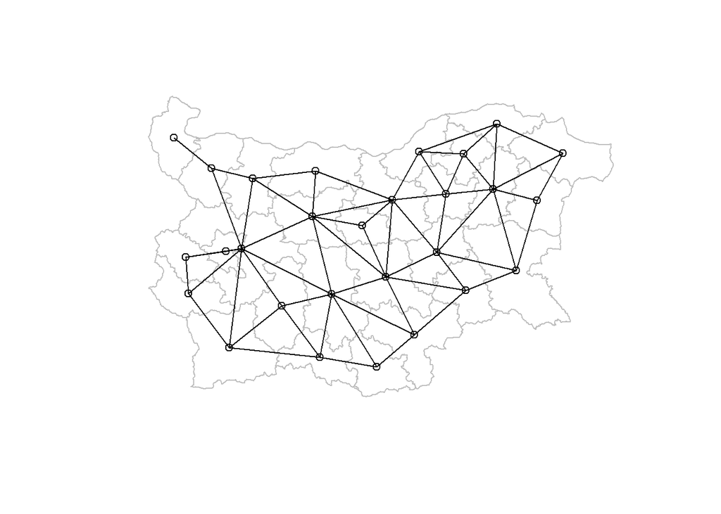

```r
plot(st_geometry(bulgaria), border="grey")
plot(contnb_q, coords, add=TRUE)
```

### Defining spatial weights

```r
dnb75.listw <- nb2listw(dnb75,style="W") #form of a list
dnb100.listw <- nb2listw(dnb100,style="W")
listw2mat(dnb75.listw)
```

```
##         [,1] [,2] [,3] [,4]      [,5]      [,6] [,7] [,8] [,9] [,10]     [,11]
## 1  0.0000000  0.0  0.0 0.00 0.0000000 0.0000000  0.0 0.00  0.0   0.0 0.0000000
## 2  0.0000000  0.0  0.0 0.00 0.0000000 0.0000000  0.0 0.00  0.0   0.0 0.0000000
## 3  0.0000000  0.0  0.0 0.00 0.0000000 0.0000000  0.0 1.00  0.0   0.0 0.0000000
## 4  0.0000000  0.0  0.0 0.00 0.0000000 0.0000000  0.0 0.25  0.0   0.0 0.2500000
## 5  0.0000000  0.0  0.0 0.00 0.0000000 0.0000000  0.5 0.00  0.0   0.0 0.0000000
## 6  0.0000000  0.0  0.0 0.00 0.0000000 0.0000000  0.0 0.00  0.0   0.0 0.3333333
## 7  0.0000000  0.0  0.0 0.00 0.5000000 0.0000000  0.0 0.00  0.0   0.0 0.0000000
## 8  0.0000000  0.0  0.5 0.50 0.0000000 0.0000000  0.0 0.00  0.0   0.0 0.0000000
## 9  0.0000000  0.0  0.0 0.00 0.0000000 0.0000000  0.0 0.00  0.0   1.0 0.0000000
## 10 0.0000000  0.0  0.0 0.00 0.0000000 0.0000000  0.0 0.00  0.5   0.0 0.0000000
## 11 0.0000000  0.0  0.0 0.20 0.0000000 0.2000000  0.0 0.00  0.0   0.0 0.0000000
## 12 0.0000000  0.0  0.0 0.00 0.0000000 0.0000000  0.5 0.00  0.0   0.5 0.0000000
## 13 0.0000000  0.0  0.0 0.00 0.0000000 0.0000000  0.0 0.00  0.0   0.0 0.0000000
## 14 0.3333333  0.0  0.0 0.00 0.0000000 0.0000000  0.0 0.00  0.0   0.0 0.0000000
```

[output cut: 101 more lines]

### Building free-form spatial weight matrices

```r
#weights as inverse functions of the distance among centroids
distM <- st_distance(coords)/1000
class(distM) <- "matrix" #distance matrix
distM
```

```
##            [,1]      [,2]      [,3]      [,4]      [,5]      [,6]      [,7]
##  [1,]   0.00000 303.52345 365.62326 283.08689  84.99646 173.18902 117.65779
##  [2,] 303.52345   0.00000 138.46415  92.77764 232.11351 157.01498 245.93218
##  [3,] 365.62326 138.46415   0.00000  85.04377 281.39987 192.45237 268.87110
##  [4,] 283.08689  92.77764  85.04377   0.00000 200.08789 111.11991 194.70584
##  [5,]  84.99646 232.11351 281.39987 200.08789   0.00000  89.15651  50.55515
##  [6,] 173.18902 157.01498 192.45237 111.11991  89.15651   0.00000  89.42579
##  [7,] 117.65779 245.93218 268.87110 194.70584  50.55515  89.42579   0.00000
##  [8,] 328.09735  80.29131  58.81637  49.44165 246.61943 158.52641 243.81978
##  [9,] 142.48181 401.21482 420.62309 350.97531 173.30993 246.29665 157.27099
## [10,]  94.21970 351.84510 380.83647 307.13015 121.59828 199.26311 112.55416
## [11,] 231.37624 114.32799 134.68884  52.14532 147.99825  58.97463 144.20083
## [12,]  78.09283 306.16644 337.61825 262.33763  77.27548 153.70083  68.77139
## [13,] 110.06513 330.17683 424.81352 339.79669 171.28241 242.68345 216.92689
## [14,]  62.31345 364.77698 427.15791 345.10587 145.80615 234.74714 170.72821
```

[output cut: 110 more lines]

```r
# Three possible weight matrices
#using inverse functions of the matrices
W1 <- 1/(1+distM); diag(W1) <- 0
W2 <- 1/(1+distM^2); diag(W2) <- 0
W3 <- exp(0.1*-distM);diag(W3) <- 0

#Row-standardize them
W1s <- W1/rowSums(W1)
W2s <- W2/rowSums(W2)
W3s <- W3/rowSums(W3)
#convert
listW1s <- mat2listw(W1s)
listW2s <- mat2listw(W2s)
listW3s <- mat2listw(W3s)
```

# The Moran’s I test of spatial autocorrelation

(a global measure)

First, let’s merge data from the Bulgarian Statistical Institute as well.

```r
library(readxl)
bgstats <- read_excel("C:\\Users\\User\\Documents\\UNITN\\Geospatial\\For_GITHUB_project\\R_SpatialRegression\\BG_statistics.xlsx")
colnames(bgstats)[1] = "NAME_LATN"
prov <- merge(bulgaria, bgstats, by="NAME_LATN")
head(prov)
```

|  | NAME_LATN | NUTS_NAME | Pop_2019 | Pop_city | Pop_villag | Area | precipitation_average | temperature_average | wind_speed_average | waterused | PublicWaterSupply | GeneratedMunicipalWaste | AccommodationEstablishments | HealthEstablishments | GDPmlnbg | geometry |
| --- | --- | --- | --- | --- | --- | --- | --- | --- | --- | --- | --- | --- | --- | --- | --- | --- |
| 1 | Blagoevgrad | Благоевград | 302694 | 182137 | 120557 | 6450 | 48.48020 | 8.723247 | 2.613756 | 113 | 99.65 | 97.830 | 228 | 11 | 3134.287 |  |
| 2 | Burgas | Бургас | 409265 | 313132 | 96133 | 7752 | 47.58953 | 11.841585 | 2.929849 | 108 | 99.94 | 160.636 | 773 | 19 | 4578.747 |  |
| 3 | Dobrich | Добрич | 171809 | 118492 | 53317 | 4719 | 41.55063 | 11.072057 | 3.560082 | 84 | 99.88 | 68.606 | 152 | 7 | 1743.875 |  |
| 4 | Gabrovo | Габрово | 106598 | 87265 | 19333 | 2023 | 52.56989 | 10.062855 | 2.629384 | 100 | 98.81 | 44.547 | 62 | 7 | 1555.871 |  |
| 5 | Haskovo | Хасково | 225317 | 162659 | 62658 | 5532 | 48.73795 | 12.207570 | 2.126110 | 84 | 99.45 | 67.914 | 35 | 11 | 2042.577 |  |
| 6 | Kardzhali | Кърджали | 158204 | 63856 | 94348 | 3211 | 50.82483 | 11.332915 | 2.309456 | 83 | 90.36 | 35.201 | 52 | 6 | 1759.839 |  |

Below are some plots of several variables.

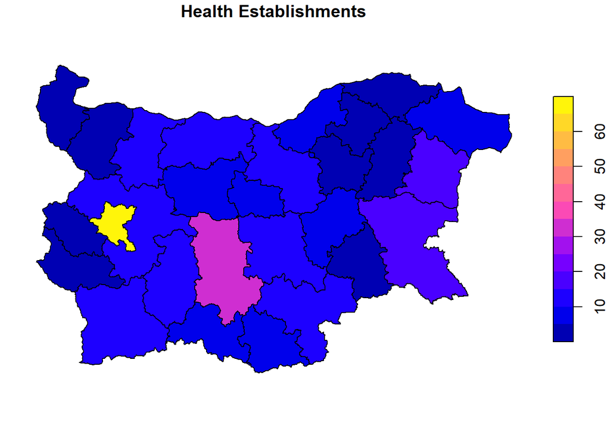

```r
plot(prov[c("HealthEstablishments")], main="Health Establishments")
```

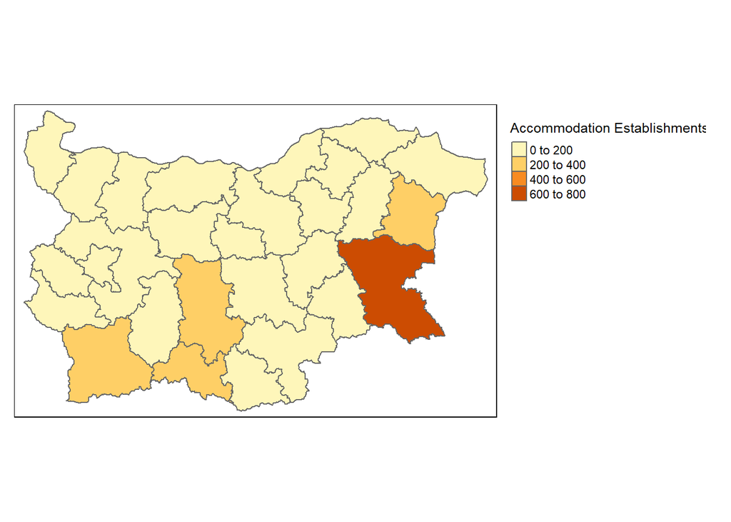

```r
tm_shape(prov) +
  tm_polygons("AccommodationEstablishments", title = "Accommodation Establishments") +
  tm_layout(legend.outside = TRUE)
```

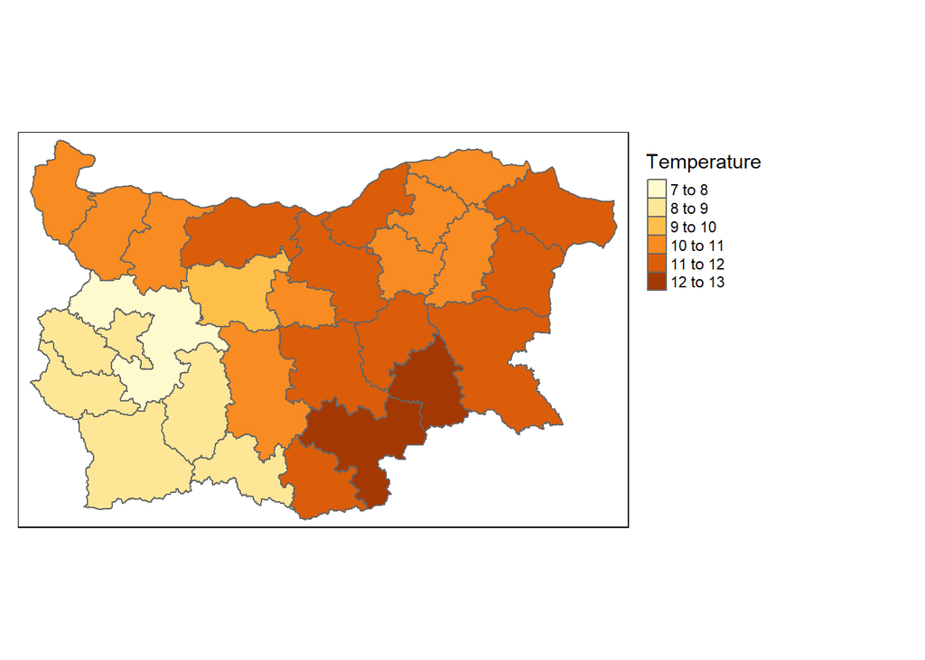

```r
tm_shape(prov) +
  tm_polygons("temperature_average", title = "Temperature") +
  tm_layout(legend.outside = TRUE)
```

```r
require(RColorBrewer)
qpal <- colorQuantile("OrRd", prov$GDPmlnbg, n=9)
leaflet(prov) %>%
  addPolygons(stroke = FALSE, fillOpacity = .8, smoothFactor = 0.2, color = ~qpal(GDPmlnbg)) %>%
  addTiles()
```

[interactive chart not shown]

## Moran’s test

Trying different variables, but it appears that p-values are quite high, so it seems that Spatial autocorrelation of the variables is not statistically significant.

```r
# GDP
moran.mc(prov$GDPmlnbg, dnb75.listw, nsim = 999)
```

```
##
##  Monte-Carlo simulation of Moran I
##
## data:  prov$GDPmlnbg
## weights: dnb75.listw
## number of simulations + 1: 1000
##
## statistic = -0.00014423, observed rank = 808, p-value = 0.192
## alternative hypothesis: greater
```

```r
#Temperature, try a different matrix
moran.test(prov$temperature_average, dnb100.listw, randomisation = TRUE)
```

```
##
##  Moran I test under randomisation
##
## data:  prov$temperature_average
## weights: dnb100.listw
##
## Moran I statistic standard deviate = -1.2059, p-value = 0.8861
## alternative hypothesis: greater
## sample estimates:
## Moran I statistic       Expectation          Variance
##       -0.17265214       -0.03703704        0.01264722
```

```r
moran.mc(prov$temperature_average, listW1s, nsim=999)
```

```
##
##  Monte-Carlo simulation of Moran I
##
## data:  prov$temperature_average
## weights: listW1s
## number of simulations + 1: 1000
##
## statistic = -0.042736, observed rank = 470, p-value = 0.53
## alternative hypothesis: greater
```

```r
moran.test(prov$precipitation_average, dnb100.listw, randomisation = TRUE)
```

```
##
##  Moran I test under randomisation
##
## data:  prov$precipitation_average
## weights: dnb100.listw
##
## Moran I statistic standard deviate = -0.51465, p-value = 0.6966
## alternative hypothesis: greater
## sample estimates:
## Moran I statistic       Expectation          Variance
##       -0.09341955       -0.03703704        0.01200224
```

```r
moran.mc(prov$precipitation_average, listW1s, nsim=999)
```

```
##
##  Monte-Carlo simulation of Moran I
##
## data:  prov$precipitation_average
## weights: listW1s
## number of simulations + 1: 1000
##
## statistic = -0.054268, observed rank = 297, p-value = 0.703
## alternative hypothesis: greater
```

```r
moran.test(prov$GeneratedMunicipalWaste, dnb100.listw, randomisation = TRUE)
```

```
##
##  Moran I test under randomisation
##
## data:  prov$GeneratedMunicipalWaste
## weights: dnb100.listw
##
## Moran I statistic standard deviate = -0.34658, p-value = 0.6355
## alternative hypothesis: greater
## sample estimates:
## Moran I statistic       Expectation          Variance
##      -0.062065237      -0.037037037       0.005215014
```

```r
moran.mc(prov$GeneratedMunicipalWaste, listW1s, nsim=999)
```

```
##
##  Monte-Carlo simulation of Moran I
##
## data:  prov$GeneratedMunicipalWaste
## weights: listW1s
## number of simulations + 1: 1000
##
## statistic = -0.043815, observed rank = 450, p-value = 0.55
## alternative hypothesis: greater
```

```r
moran.mc(prov$wind_speed_average, listW1s, nsim=999)
```

```
##
##  Monte-Carlo simulation of Moran I
##
## data:  prov$wind_speed_average
## weights: listW1s
## number of simulations + 1: 1000
##
## statistic = -0.0092486, observed rank = 819, p-value = 0.181
## alternative hypothesis: greater
```

### The Moran’s I test of spatial autocorrelation in OLS residuals of a linear regression model

```r
Lm1 <- lm(temperature_average ~ precipitation_average + wind_speed_average, prov)
summary(Lm1)
```

```
##
## Call:
## lm(formula = temperature_average ~ precipitation_average + wind_speed_average,
##     data = prov)
##
## Residuals:
##      Min       1Q   Median       3Q      Max
## -2.00639 -0.45042  0.09639  0.53276  1.50555
##
## Coefficients:
##                       Estimate Std. Error t value Pr(>|t|)
## (Intercept)           32.13380    3.31975   9.680 6.16e-10 ***
## precipitation_average -0.32500    0.05355  -6.069 2.43e-06 ***
## wind_speed_average    -2.16096    0.51003  -4.237 0.000269 ***
## ---
## Signif. codes:  0 '***' 0.001 '**' 0.01 '*' 0.05 '.' 0.1 ' ' 1
##
## Residual standard error: 0.8301 on 25 degrees of freedom
## Multiple R-squared:  0.6327, Adjusted R-squared:  0.6033
## F-statistic: 21.53 on 2 and 25 DF,  p-value: 3.654e-06
```

```r
#plot of the studentized residuals
prov$studres <- rstudent(Lm1)
qpal <- colorQuantile("OrRd", prov$studres, n=4)
leaflet(prov) %>%
  addPolygons(stroke = FALSE, fillOpacity = .8, smoothFactor = 0.2, color = ~qpal(studres)) %>%
  addTiles()
```

[interactive chart not shown]

```r
#There can be seen some similarities in the residuals in some regions which are close next to each other.
```

```r
#Applying the Moran's I test in the OLS residuals
lm.morantest(Lm1,dnb100.listw,resfun=rstudent)
```

```
##
##  Global Moran I for regression residuals
##
## data:
## model: lm(formula = temperature_average ~ precipitation_average +
## wind_speed_average, data = prov)
## weights: dnb100.listw
##
## Moran I statistic standard deviate = 0.10416, p-value = 0.4585
## alternative hypothesis: greater
## sample estimates:
## Observed Moran I      Expectation         Variance
##      -0.02572142      -0.03737117       0.01250909
```

```r
lm.morantest(Lm1,listW1s,resfun=rstudent)
```

```
##
##  Global Moran I for regression residuals
##
## data:
## model: lm(formula = temperature_average ~ precipitation_average +
## wind_speed_average, data = prov)
## weights: listW1s
##
## Moran I statistic standard deviate = 1.1868, p-value = 0.1177
## alternative hypothesis: greater
## sample estimates:
## Observed Moran I      Expectation         Variance
##      0.002569266     -0.037039875      0.001113963
```

Again not really significant even though a bit lower p-values.

```r
library(boot)
Lm1.lmx <- lm(temperature_average ~ precipitation_average + wind_speed_average, data = prov, x = TRUE)
MoraneI.boot <- function(var, i, ...) {
  var <- var[i]
  lmres <- lm(var ~ Lm1.lmx$x - 1)
  return(moran(x=residuals(lmres), ...)$I)
}
boot1 <- boot(residuals(Lm1.lmx),statistic=MoraneI.boot,
                R=999, sim="permutation", listw=listW1s,
                n=length(listW1s$neighbours), S0=Szero(listW1s))
ti <- (boot1$t0 - mean(boot1$t))/sqrt(var(boot1$t))
boot1
```

```
##
## DATA PERMUTATION
##
##
## Call:
## boot(data = residuals(Lm1.lmx), statistic = MoraneI.boot, R = 999,
##     sim = "permutation", listw = listW1s, n = length(listW1s$neighbours),
##     S0 = Szero(listW1s))
##
##
## Bootstrap Statistics :
##         original      bias    std. error
## t1* 0.0004070047 -0.03806616  0.03216545
```

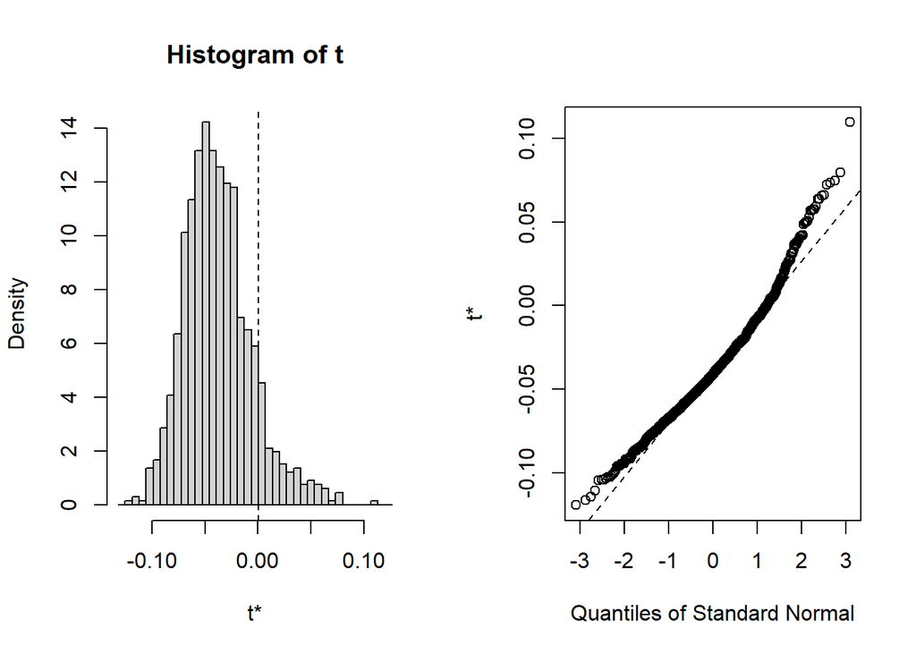

```r
plot(boot1)
```

```r
# We can see there is some pattern in the residuals, they don't follow the quantiles excatly
#But still not too far off
```

# Local Moran I and test

(local spatial clusters)

## 1. Moran scatterplot

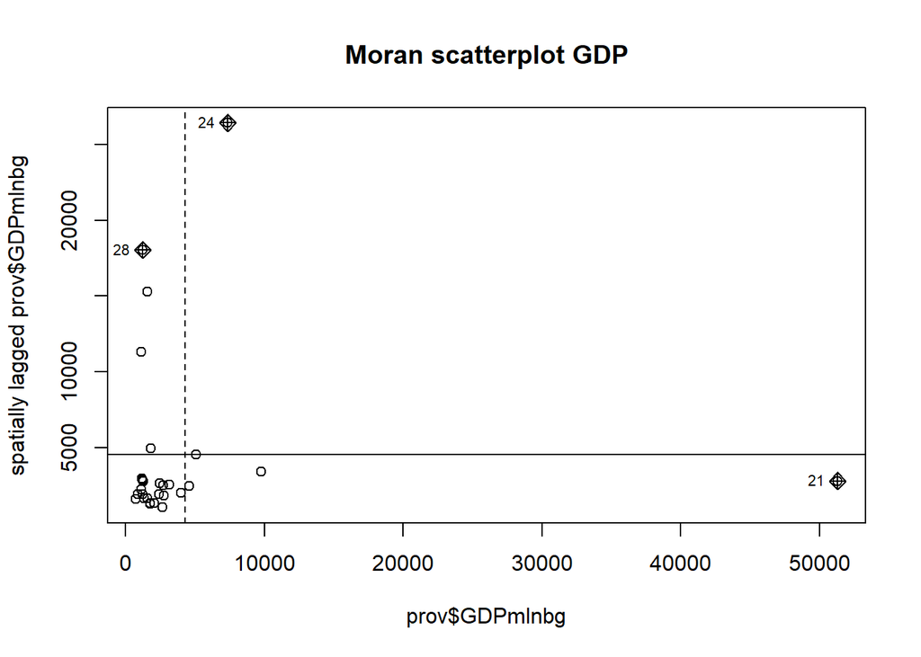

```r
#GDP
mplot <- moran.plot(prov$GDPmlnbg, listw=dnb75.listw, main="Moran scatterplot GDP")
```

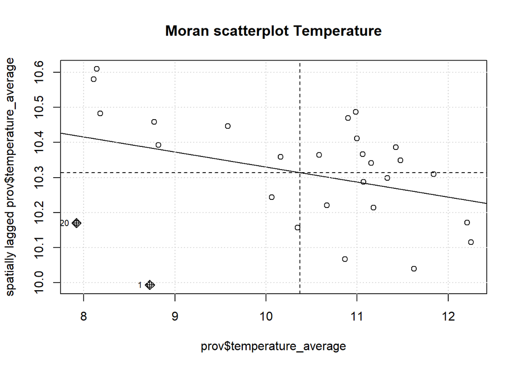

```r
# Since the pattern of Sofia is particular it is way far off, it is difficult to make inference

mplot <- moran.plot(prov$temperature_average, listw=listW1s, main="Moran scatterplot Temperature")
grid()
```

From the plot some things could be pointed out: There seem to be some division in the four quadrants; Higher temperature seems to be associated with lower local average. Sofia and Blagoevgrad exert the most influence on the regression line.

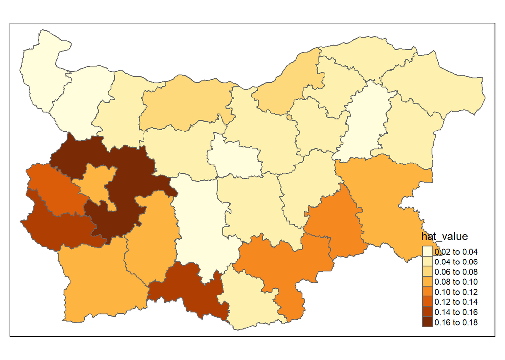

```r
prov$hat_value <- mplot$hat
tm_shape(prov) + tm_polygons("hat_value")
```

Below, the most influencial units.

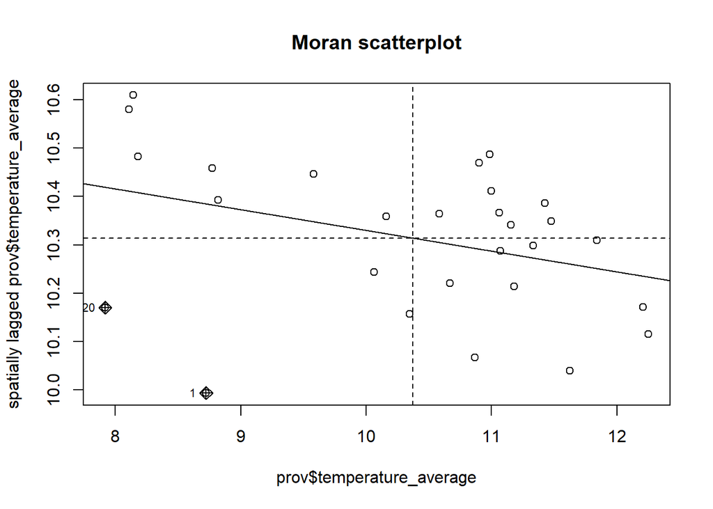

```r
mplot <- moran.plot(prov$temperature_average, listw=listW1s, main="Moran scatterplot",
         return_df=F)
```

```r
hotspot <- as.numeric(row.names(as.data.frame(summary(mplot))))
```

```
## Potentially influential observations of
##   lm(formula = wx ~ x) :
##
##    dfb.1_ dfb.x dffit   cov.r   cook.d hat
## 1  -0.87   0.80 -1.02_*  0.61_*  0.38   0.09
## 20 -0.79   0.74 -0.84_*  0.99    0.32   0.16
```

```r
prov$wx <- lag.listw(listW1s, prov$temperature_average)

prov$quadrant <- rep("None", length(prov$temperature_average))
for(i in 1:length(hotspot))  {
  if (prov$temperature_average[hotspot[i]]>mean(prov$temperature_average) & prov$wx[hotspot[i]]> mean(prov$wx))
        prov$quadrant[hotspot[i]] <- "HH"
  if (prov$temperature_average[hotspot[i]]>mean(prov$temperature_average) & prov$wx[hotspot[i]]< mean(prov$wx))
        prov$quadrant[hotspot[i]] <- "HL"
  if (prov$temperature_average[hotspot[i]]<mean(prov$temperature_average) & prov$wx[hotspot[i]]<mean(prov$wx))
        prov$quadrant[hotspot[i]] <- "LL"
  if (prov$temperature_average[hotspot[i]]<mean(prov$temperature_average) & prov$wx[hotspot[i]]>mean(prov$wx))
        prov$quadrant[hotspot[i]] <- "LH"
  }
table(prov$quadrant)
```

```
##
##   LL None
##    2   26
```

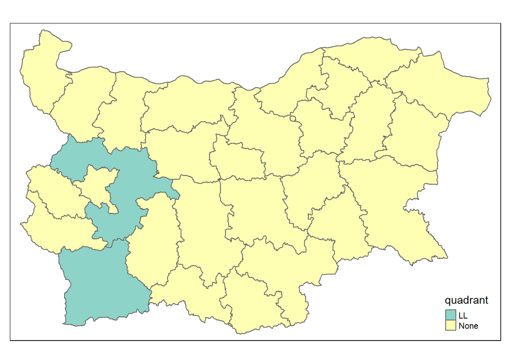

```r
#which allows us to plot the map of the regions with influence by typing
tm_shape(prov) + tm_polygons("quadrant")
```

# 2. The Local Moran’s I values

```r
lmI <- localmoran(prov$temperature_average, listW1s)
head(lmI)
```

```
##            Ii         E.Ii      Var.Ii        Z.Ii Pr(z != E(Ii))
## 1  0.37390121 -0.060194827 0.073565393  1.60047556      0.1094931
## 2 -0.05588626 -0.047669595 0.015177602 -0.06669513      0.9468244
## 3 -0.03556797 -0.010797088 0.005430731 -0.33613392      0.7367699
## 4  0.02408043 -0.002130174 0.001081662  0.79695037      0.4254799
## 5 -0.22103878 -0.074394573 0.017216213 -1.11762501      0.2637272
## 6 -0.04251241 -0.020362472 0.006240486 -0.28039054      0.7791779
```

```r
prov$lmI <- lmI[,1]
tm_shape(prov) +
    tm_polygons("lmI", title = "Local Moran's I values")
```

```
## Variable(s) "lmI" contains positive and negative values, so midpoint is set to 0. Set midpoint = NA to show the full spectrum of the color palette.
```

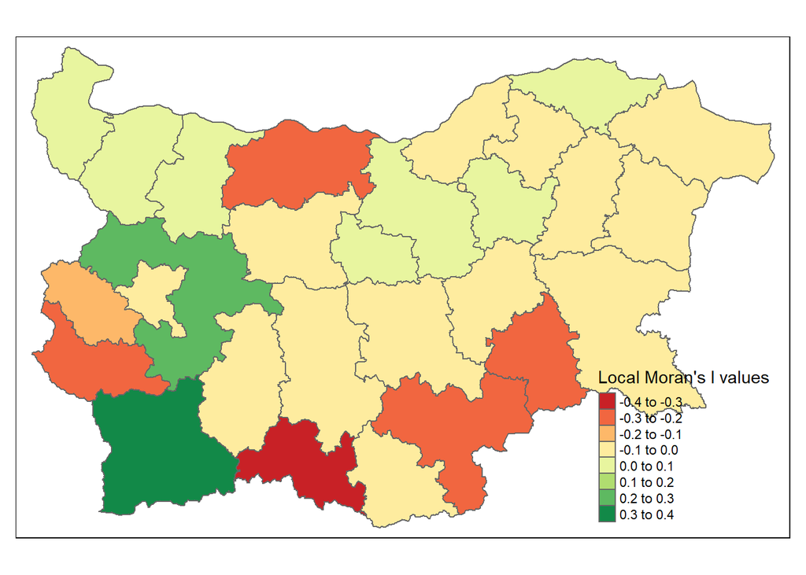

```r
# We can see some of the local regions that are being identified
```

```r
lmIp1 <- localmoran_perm(prov$temperature_average, listW1s, nsim = 9999, iseed = 1)
lmIp2 <- localmoran_perm(prov$GDPmlnbg, listW1s, nsim = 9999, iseed = 1)

#Things do not seem significant.
```

# Spatial regression

Let’s see if there exists the need to include spatial characteristics when computing models.

```r
library(spatialreg)
#The Lagrange multiplier (LM) test of spatial dependence on OLS residuals

Lm1 <- lm(temperature_average ~ precipitation_average + wind_speed_average, prov)
natOLSlmTests <- lm.LMtests(Lm1, dnb100.listw,
                    test=c("LMerr", "LMlag", "RLMerr", "RLMlag"))
summary(natOLSlmTests)
```

```
##  Lagrange multiplier diagnostics for spatial dependence
## data:
## model: lm(formula = temperature_average ~ precipitation_average +
## wind_speed_average, data = prov)
## weights: dnb100.listw
##
##        statistic parameter p.value
## LMerr   0.059965         1  0.8066
## LMlag   1.000447         1  0.3172
## RLMerr  0.874187         1  0.3498
## RLMlag  1.814669         1  0.1779
```

After having tried with different weight matrices, it seems there is no presence of importance of the spatial distribution for the model about average temperature.

```r
#Also for the GDP not preferred any other models which consider the spatial autocorrelation

Lm2 <- lm(GDPmlnbg ~ Area + PublicWaterSupply + GeneratedMunicipalWaste + AccommodationEstablishments, prov)
natOLSlmTests <- lm.LMtests(Lm2, dnb100.listw,
                    test=c("LMerr", "LMlag", "RLMerr", "RLMlag"))
summary(natOLSlmTests)
```

```
##  Lagrange multiplier diagnostics for spatial dependence
## data:
## model: lm(formula = GDPmlnbg ~ Area + PublicWaterSupply +
## GeneratedMunicipalWaste + AccommodationEstablishments, data = prov)
## weights: dnb100.listw
##
##        statistic parameter p.value
## LMerr    0.77463         1  0.3788
## LMlag    0.18334         1  0.6685
## RLMerr   0.60788         1  0.4356
## RLMlag   0.01659         1  0.8975
```

From the analysis conducted, it appears that overall in Bulgarian districts, the geographical location does not play a big role for some statistical indicators. The local/global effects cannot be seen, and in fact since the main and most developed cities of the country are more or less scattered around the country, it makes sense.

Therefore, if regression is to be done on some factor concerning the variables at hand, it can be relied on linear regression models with OLS estimator.

There could be some other indicator variables for the country, which could possibly possess the need to be analysed with the use of a spatial regression model.

In fact, maybe if analysis is done based on municipalities, some more useful and informative results could be obtained. However, not much data of this kind is available.